# Hlutapróf 2

```r
library(tidyverse)
```

Í þessu hlutaprófi ætlið þið að vinna með gögn um einkunnagjöf kvikmynda á Rotten Tomatoes síðunni. Gögnin má finna á síðunni: https://ahj.hi.is/Rotten_Tomatoes_Movies.csv

```r
dat <- read_csv("https://ahj.hi.is/Rotten_Tomatoes_Movies.csv")
```

# Spurning 1

Breytan **audience_count** lýsir því hvað kvikmyndadómar margra einstaklinga voru notaðir til að meta einkunn kvikmyndarinnar.

- Teiknið viðeigandi graf til að lýsa úrtaksdreifingu breytunnar **audience_count** og lýsið lögun breytunnar (2 stig)

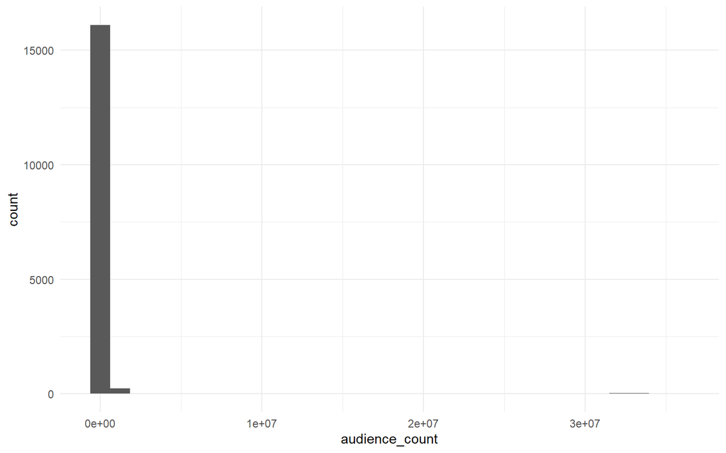

```r
library(tidyverse)

ggplot(dat, aes(x=audience_count)) +
  geom_histogram() +
  theme_minimal()
```

Þetta er hægri skekkt einkryppudreifing.

- Búið til nýja breytu með því að taka lógarithmann af **audience_count** og kallið hana **log_audience_count** (1 stig)

```r
dat <- dat %>%
  mutate(log_audience_count = log(audience_count))
```

- Teiknið viðeigandi graf til að lýsa lögun þessarar nýju breytu og lýsið lögun hennar (2 stig).

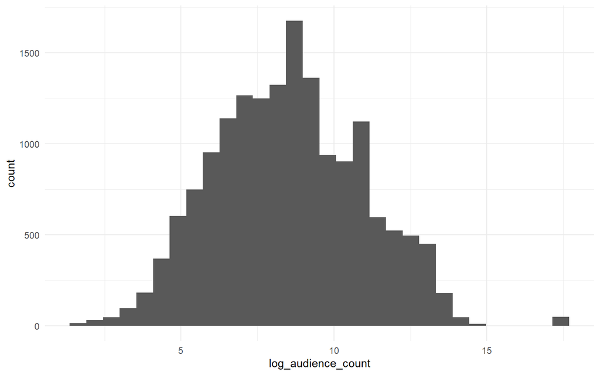

```r
ggplot(dat, aes(x=log_audience_count)) +
  geom_histogram() +
  theme_minimal()
```

Þetta er samhverf dreifing sem svipar til normaldreifingar, þó með útlögum til hægri.

# Spurning 2

Breytan **tomatometer_status** lýsir því hvort kvikmyndin flokkast sem ,,fersk’‘, ,,staðfest fersk’’ eða ,,rotin’’.

- Teiknið viðeigandi graf til að sambandi breytunnar **log_audience_count** og **tomatometer_status** (1 stig)

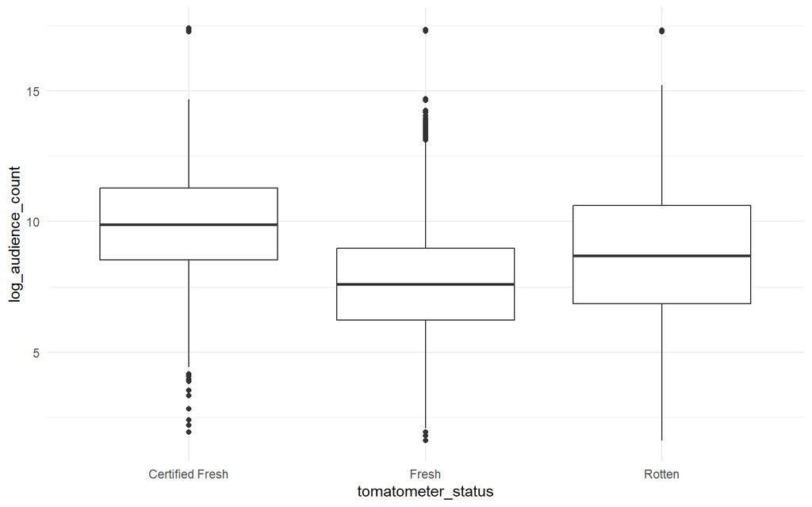

```r
ggplot(dat, aes(x=tomatometer_status, y=log_audience_count)) +
  geom_boxplot() +
  theme_minimal()
```

- Kannið með viðeigandi tilgátuprófi hvort það sé samband milli breytanna tveggja. Gætið þess að taka mjög nákvæmlega fram hvaða ályktanir þið dragið (2 stig).

```r
mod <- aov(log_audience_count~ tomatometer_status, data=dat)
anova(mod)
```

```
## Analysis of Variance Table
##
## Response: log_audience_count
##                       Df Sum Sq Mean Sq F value    Pr(>F)
## tomatometer_status     2  10146  5073.0  961.95 < 2.2e-16 ***
## Residuals          16383  86398     5.3
## ---
## Signif. codes:  0 '***' 0.001 '**' 0.01 '*' 0.05 '.' 0.1 ' ' 1
```

Við framkvæmum fervikagreiningu til að kanna núlltilgátuna hvort meðalfjöldi log_audience_count sé sá sami í öllum þremur hópum tomatometer_status. Við fengum F-gildið 961.9455461 og p-gildið 0. Við höfnum því núlltilgátunni og fullyrðum að meðaltal log_audience_count sé ekki það sama í einhverjum tveimur hópum.

- Getið þið fullyrt hvaða flokkur er með flestar einkunnagjafir per kvikmynd að meðaltali og hvaða flokkur er með fæstar einkunnagjafir per kvikmynd að meðaltali? Rökstyðjið vel svarið ykkar og framkvæmið fleiri tilgátupróf ef með þarf (2 stig).

```r
library(kableExtra)
dat %>% group_by(tomatometer_status) %>% summarize(medaltal = mean(log_audience_count, na.rm=T)) %>% kable
```

| tomatometer_status | medaltal |
| --- | --- |
| Certified Fresh | 9.914691 |
| Fresh | 7.696803 |
| Rotten | 8.666407 |

```r
TukeyHSD(mod)
```

```
##   Tukey multiple comparisons of means
##     95% family-wise confidence level
##
## Fit: aov(formula = log_audience_count ~ tomatometer_status, data = dat)
##
## $tomatometer_status
##                              diff        lwr       upr p adj
## Fresh-Certified Fresh  -2.2178888 -2.3380358 -2.097742     0
## Rotten-Certified Fresh -1.2482850 -1.3660330 -1.130537     0
## Rotten-Fresh            0.9696038  0.8765246  1.062683     0
```

Við framkvæmum Tukey eftirápróf til að bera saman meðaltöl log_audience_count milli sérhverra tveggja og tveggja hópa tomatometer_status. Við fáum að meðaltöl allra þriggja hópanna séu ólík, Fresh er með minnsta meðaltalið en Certified Fresh með það stærsta.

# Spurning 3

Breytan **audience_rating** lýsir því hversu góð almenningi fannst myndin.

- Teiknið graf sem lýsir sambandi **log_audience_count** og **audience_rating** (1 stig).

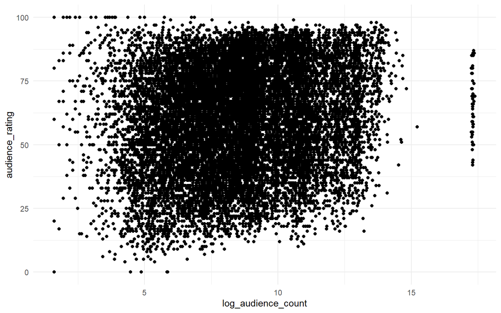

```r
ggplot(dat, aes(x=log_audience_count, y=audience_rating)) +
  geom_point() +
  theme_minimal()
```

- Kannið með viðeigandi tilgátuprófi samband breytanna **log_audience_count** og **audience_rating**. Gætið þess að taka mjög nákvæmlega fram hvaða ályktanir þið dragið (2 stig).

Hér má hvort heldur sem er meta línulegt aðhvarfsgreiningarlíkan og kanna hvort hallatalan aðhvarfslínunnar sé núll eða reikna fylgni milli breytanna tveggja.

Metum fyrst línulegt aðhvarfsgreiningarlíkan

```r
mod2 <- lm(audience_rating~ log_audience_count, data= dat)
summary(mod2)
```

```
##
## Call:
## lm(formula = audience_rating ~ log_audience_count, data = dat)
##
## Residuals:
##     Min      1Q  Median      3Q     Max
## -56.941 -15.819   2.004  16.747  48.731
##
## Coefficients:
##                    Estimate Std. Error t value Pr(>|t|)
## (Intercept)        49.12570    0.57610   85.27   <2e-16 ***
## log_audience_count  1.33160    0.06503   20.48   <2e-16 ***
## ---
## Signif. codes:  0 '***' 0.001 '**' 0.01 '*' 0.05 '.' 0.1 ' ' 1
##
## Residual standard error: 20.21 on 16384 degrees of freedom
##   (252 observations deleted due to missingness)
## Multiple R-squared:  0.02495,    Adjusted R-squared:  0.02489
## F-statistic: 419.3 on 1 and 16384 DF,  p-value: < 2.2e-16
```

```r
cor.test(dat$audience_rating,dat$log_audience_count)
```

```
##
##  Pearson's product-moment correlation
##
## data:  dat$audience_rating and dat$log_audience_count
## t = 20.476, df = 16384, p-value < 2.2e-16
## alternative hypothesis: true correlation is not equal to 0
## 95 percent confidence interval:
##  0.1429985 0.1728575
## sample estimates:
##       cor
## 0.1579641
```

Hér prófum við núlltilgátuna hvort fylgni **log_audience_count** og **audience_rating** sé núll. Við fáum sama t-gildi og p-gildi og í aðhvarfsgreiningarlíkaninu svo við höfnum núlltilgátunni og fullyrðum að það sé jákvæð fylgni milli **log_audience_count** og **audience_rating**.

- Hvað spáið þið að kvikmynd sem 20000 manns gáfu einkunn fái í einkunn á **audience_rating**. Birtið bæði spána og 95% spábil (2 stig).

Ábending: Ef breytan **audience_count** tekur gildið 20000 þá tekur breytan **log_audience_count** gildið log(20000).

Hér verðum við að meta línulegt aðhvarfsgreiningar líkan og fá spágildi út úr því.

```r
mod2 <- lm(audience_rating~ log_audience_count, data= dat)
predict(mod2, newdata=data.frame(log_audience_count = log(20000)), interval='prediction')
```

```
##        fit     lwr      upr
## 1 62.31321 22.7055 101.9209
```

Við spáum að kvikmynd sem 20000 manns gáfu einkunn fái 62.3132104 í einkunn með 95% spábil frá 22.7055017 upp í 101.9209191

# Spurning 4

Samband **genre** og **tomatometer_status**.

Breytan **genre** lýsir því af hvaða tegund hver kvikmynd er.

- Búið til nýja breytu sem segir til um hvort orðið ,,Drama’’ kemur einhvers staðar fyrir í lýsingunni á tegund myndarinnar (1 stig). Þessi kóði getur hjálpað ykkur:

```r
library(stringr)
dat <- dat %>% mutate(drama = str_detect(genre, 'Drama'))
```

Ef þið náið ekki að búa til þessa breytu, búið þá til breytu sem gefur til kynna tegund myndarinnar sé nákvæmlega “Drama” eða ekki.

- Búið til töflu sem lýsir hlutfalli kvikmynda sem hafa orðið ,,Drama’’ í nafninu eftir **tomatometer_status** (2 stig).

```r
dat %>% group_by(tomatometer_status) %>%
  summarize(hlutfall = mean(drama, na.rm=T)) %>%
  kable()
```

| tomatometer_status | hlutfall |
| --- | --- |
| Certified Fresh | 0.6160352 |
| Fresh | 0.5582660 |
| Rotten | 0.4968875 |

- Kannið með viðeigandi tilgátuprófi samband breytunnar **tomatometer_status** og þessarar nýju breytu. Gætið þess að taka mjög nákvæmlega fram hvaða ályktanir þið dragið (2 stig).

```r
table(dat$tomatometer_status,dat$drama) %>% prop.test()
```

```
##
##  3-sample test for equality of proportions without continuity correction
##
## data:  .
## X-squared = 131.39, df = 2, p-value < 2.2e-16
## alternative hypothesis: two.sided
## sample estimates:
##    prop 1    prop 2    prop 3
## 0.3839648 0.4417340 0.5031125
```

Við framkvæmum kí-kvaðrat próf til að kanna núlltilgátuna hvort hlutfall mynda þar sem orðið ,,Drama’’ kemur einhvers staðar fyrir í lýsingunni á tegund myndarinnar sé það sama í öllum þremur hópum af tomatometer_status. Við fáum kí-kvaðrat gildið 131.39 og p-gildið 2.9478303^{-29} svo við höfnum núlltilgátunni og ályktum að þetta hlutfall sé ólíkt milli a.m.k. einhverra tveggja flokka tomatometer_status.